# Parenting Observational Study E2 Coding

Emily, Vivian, George

2020-03-27

Looking at the effect of electronically-delivered parenting interventions on parent-child interactions. Parents in the experimental condition viewed a video (designed for a parenting app) demonstrating an activity they could do with their child. Parents in the control condition did not view a video. Both groups of parents were asked to play with their child for 3 minutes with a set of props that matched the video demonstration they had seen. Children were 6-24 months of age. There were 6 videos total (2 per age group). Assignment to videos/sets of toys was counterbalanced within age groups. Parents also completed the Parenting Attitudes Questionnaire. Videos of the play sessions were coded for bids for joint attention, episodes of passive joint attention, and episodes of coordinated joint attention.

# 1 Data preprocessing

Preliminaries.

Read in files and consolidate to the same directory.

```
##  [1] 131 159 169 170 171 174 175 175 176 177 178 178 178 179 179 179 179 180 180
## [20] 181 181 181 181 181 181 182 182 182 182 182 182 182 182 182 182 182 182 182
## [39] 183 183 183 183 183 183 184 184 185 185 185 185 185 186 186 186 186 186 187
## [58] 187 187 188 188 188 188 188 188 189 190 190 190 192 192 192 193 194 195 195
## [77] 196 199 200 200 203 213 221 237
```

```
##    Min. 1st Qu.  Median    Mean 3rd Qu.    Max.
##   131.0   181.0   183.0   184.9   188.0   237.0
```

```
## [1] "121317_1.csv episode with negative duration!"
```

```
##           SID line phase_length pja cja bid vid_duration
## 1094 121317_1   17          -68   1   0   1          181
```

Read in trial info

```r
conditions <- read.csv("conditions.csv") %>%
  transmute(SID = sid, condition=condition, video=video, label=label)

d <- left_join(d.raw, conditions, by="SID")

#d$age[d$sid=="111517_3"] = "2"
```

# 2 Reliability

Import reliability coder’s data (25 participants were coded for reliability).

```r
d.long_rel <- combine_datavyu_files("rel_data/")

d.long_rel[which(d.long_rel$phase_length<3000),c("cja","pja")] = 0 # any episodes <3s not counted (except bids)

# summarise per subject
d.raw_rel <- d.long_rel %>% group_by(SID) %>%
  mutate(vid_duration = vid_duration / 60, # seconds to minutes
         phase_length = phase_length / 1000) %>% # ms to s
  summarise(bids=sum(bid), pja_length=sum(pja*phase_length), cja_length=sum(cja*phase_length),
            pja=sum(pja), cja=sum(cja), vid_duration=vid_duration[1]) %>%
  mutate(total_ja = pja + cja, total_lja = pja_length + cja_length)

# normalize to rates (e.g., bids/minute)
d.raw_rel[,2:9] = d.raw_rel[,2:9] / d.raw_rel$vid_duration
```

Reliability.

```r
d.raw_rel <- d.raw_rel %>%
  mutate(bids_rel = bids, pja_rel = pja, cja_rel = cja, l_pja_rel = pja_length, l_cja_rel = cja_length) %>%
  select(SID, bids_rel, pja_rel, cja_rel, l_cja_rel, l_pja_rel)

d.raw <- d.raw %>% mutate(l_pja = pja_length, l_cja = cja_length)
# 110416_03 l_cja_rel = -25889, which shouldn't be possible (incomplete final row of file)
# 121516_01 has NA bids_rel, pja_rel, and cja_rel..
# 111716_08 l_cja = -49923, which shouldn't be possible

# 110416_05, 050116_01, and 092216_03: reliability coder saw no passive JA
d_rel <- d.raw_rel %>% left_join(d.raw, by="SID") %>%
  select(SID, bids, bids_rel, pja, pja_rel, cja, cja_rel, l_cja, l_cja_rel, l_pja, l_pja_rel)

get_ICC2 <- function(dat)  {
  rel = psych::ICC(dat, missing = FALSE, alpha = 0.05)
  return(rel$results[2,])
}

bids_rel = get_ICC2(d_rel[,c("bids","bids_rel")]) # .81 [.62,.91]

pja_rel = get_ICC2(d_rel[,c("pja","pja_rel")]) # .74 eps pass JA [.48,.88]

cja_rel = get_ICC2(d_rel[,c("cja","cja_rel")]) # .80 eps coord JA [.61,.91]

l_pja_rel = get_ICC2(d_rel[,c("l_pja","l_pja_rel")]) # .72 pass JA length [.44,.86]

l_cja_rel = get_ICC2(d_rel[,c("l_cja","l_cja_rel")]) # .88 coord JA length [.75,.94]
```

Inter-rater reliability is very high for length of coordinated JA (0.88), high for bids (0.81) and episodes of coordinated JA (0.8), and not bad for episodes (0.74) and duration of passive JA (0.72).

# 3 Plots

Total number of bids (successful and unsuccessful)

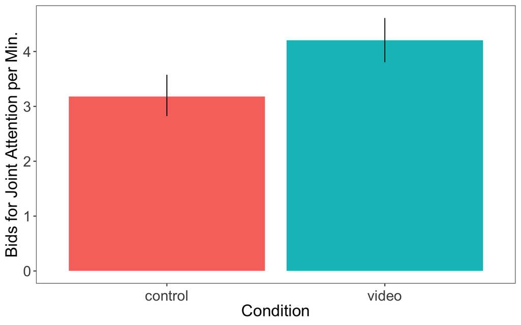

```r
dem <- read.csv("../anonymized_demographics_parenting_obs_e2.csv", header=T)
dem$age = as.numeric(as.character(dem$age))
d$age = NULL
d <- d %>% left_join(dem, by="SID") %>%
  filter(age <= 2.0) # 1 kid exactly 2...

save(d, file="Exp2_joint_attention_data.RData")

d$condition <- factor(d$condition, levels = c("con", "exp"), labels = c("control", "video"))

ms_bids <- d %>%
  group_by(condition) %>%
  multi_boot_standard(col = "bids")

ggplot(ms_bids, aes(x = condition, y = mean, fill = condition)) +
  geom_bar(stat="identity") +
  geom_linerange(aes(ymin = ci_lower, ymax = ci_upper),
             position = position_dodge(width = .9))+
  xlab("Condition") + ylab("Bids for Joint Attention per Min.") +
  langcog::scale_colour_solarized() + theme(legend.position="none")
```

Total episodes of joint attention.

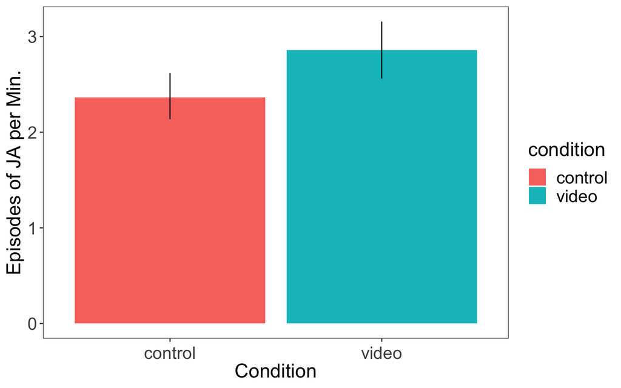

Episodes of passive joint attention.

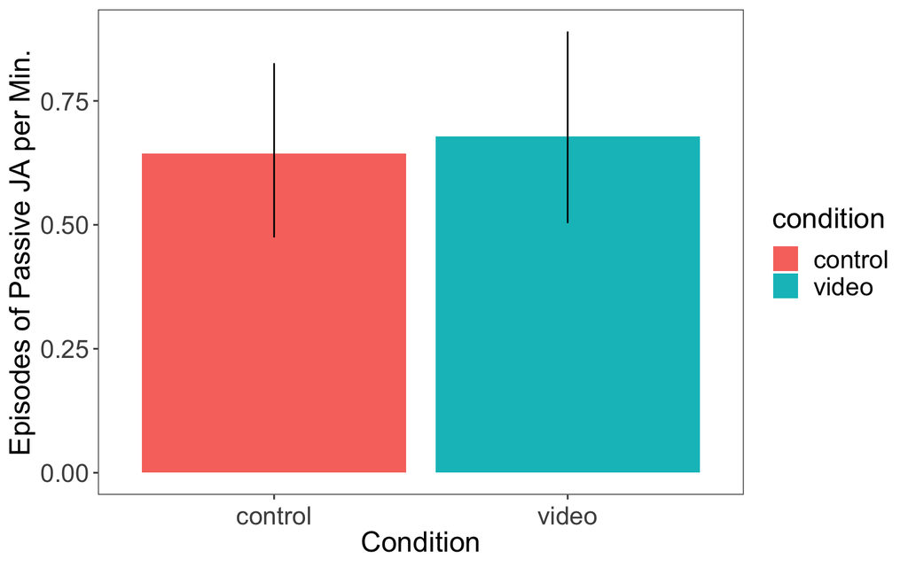

Episodes of coordinated joint attention

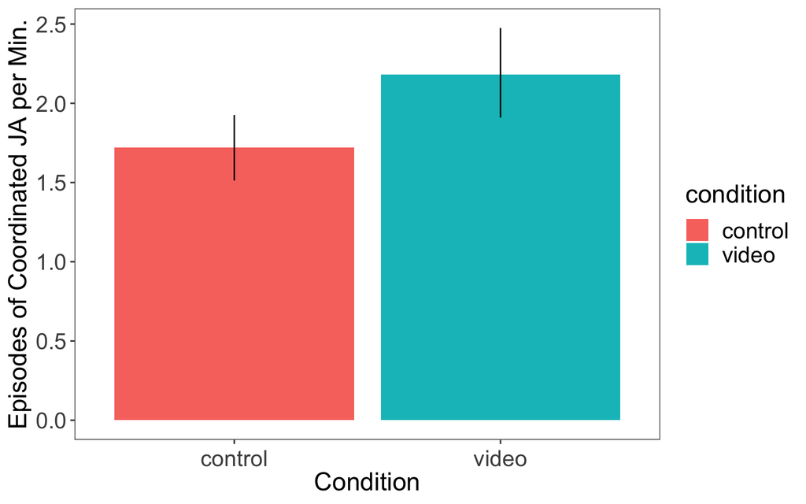

Rate of passive joint attention.

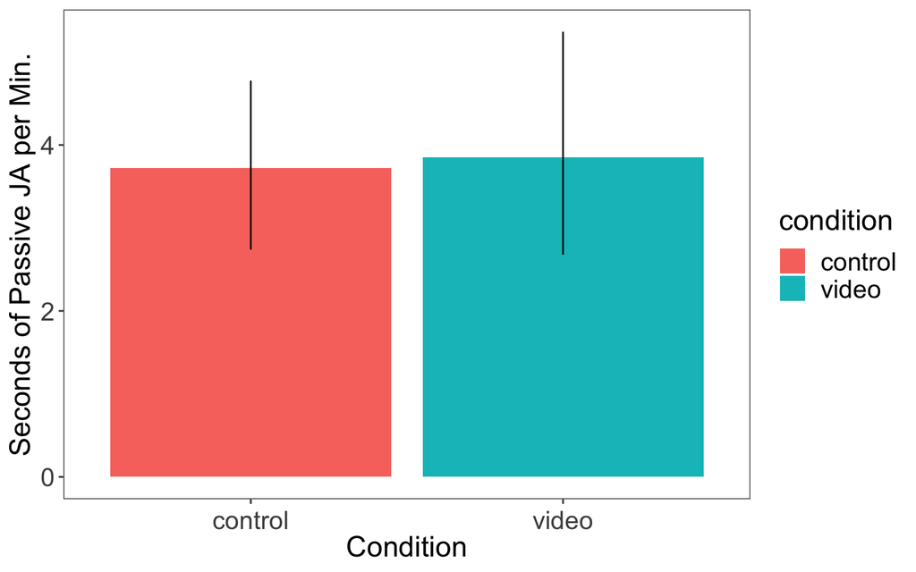

Rate of coordinated joint attention.

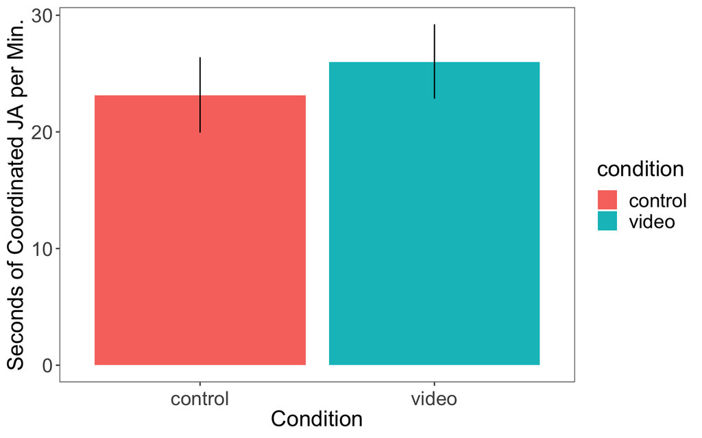

## 3.1 Demographics

### 3.1.1 Child gender

Total bids by gender.

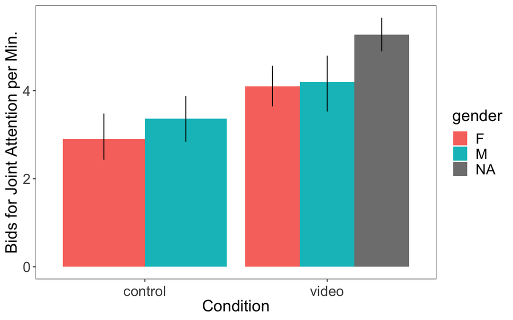

Rate of passive joint attention by gender

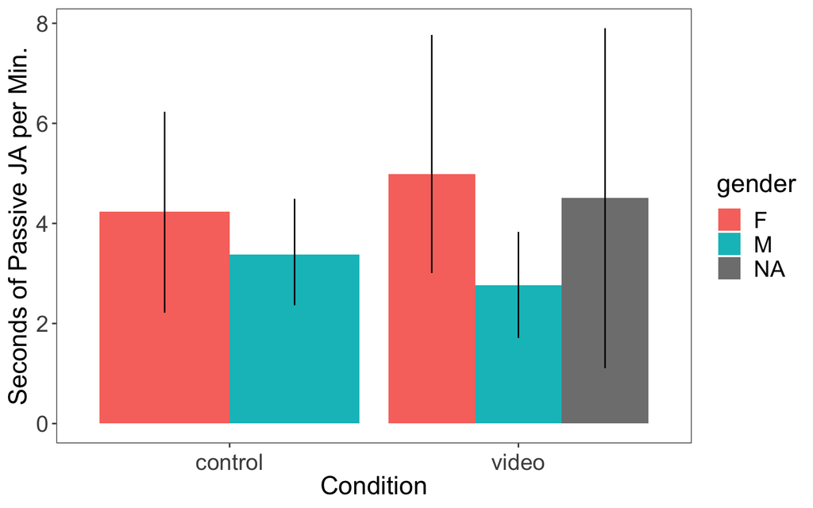

Rate of coordinated joint attention by gender

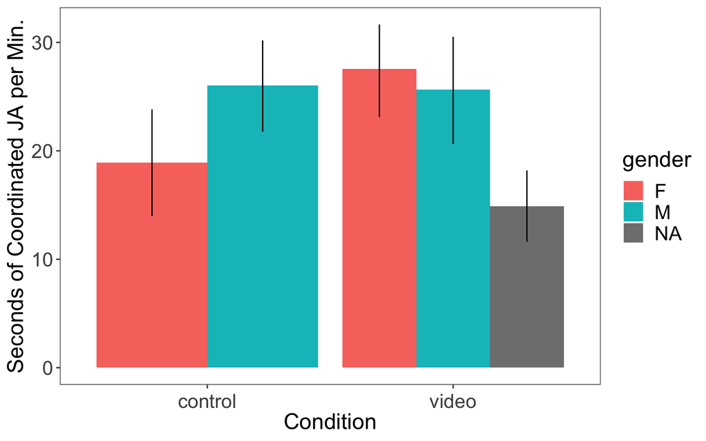

### 3.1.2 Child age

Total bids by age.

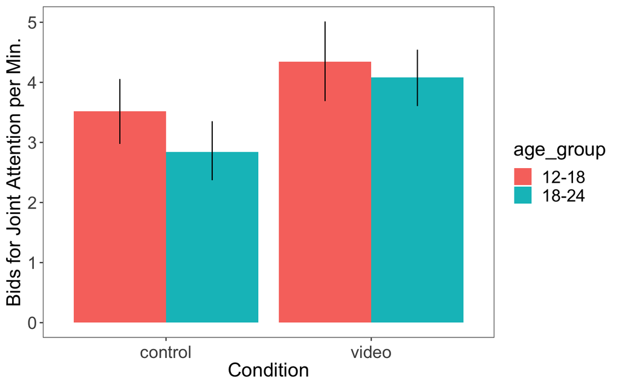

Rate of passive joint attention by age

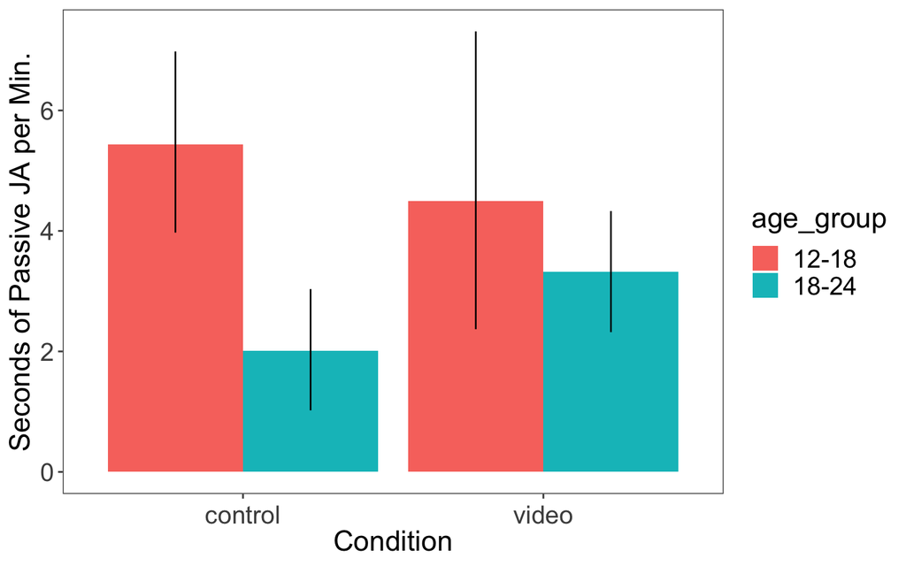

Rate of coordinated joint attention by age

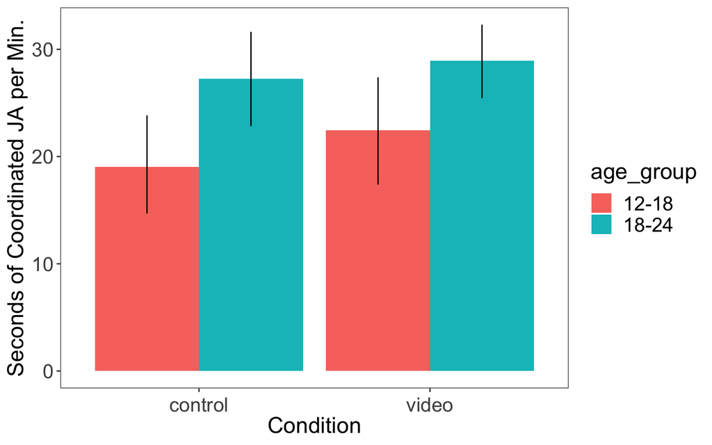

# 4 Analysis

Is the duration of joint attention correlated with age?

```
##              age pja_length cja_length total_lja
## age         1.00      -0.34       0.39      0.29
## pja_length -0.34       1.00      -0.42     -0.07
## cja_length  0.39      -0.42       1.00      0.93
## total_lja   0.29      -0.07       0.93      1.00
##
## n= 84
##
##
## P
##            age    pja_length cja_length total_lja
## age               0.0014     0.0003     0.0075
## pja_length 0.0014            0.0000     0.5330
## cja_length 0.0003 0.0000                0.0000
## total_lja  0.0075 0.5330     0.0000
```

Mixed effects models.

Prepare data.

```r
lmer_data <- d %>%
  mutate(Condition = factor(condition),
         bids = as.numeric(bids),
         age = as.numeric(langcog::scale(age, scale=FALSE)),
         gender = as.factor(gender),
         Video = as.factor(video))
```

Total number of bids

```r
lmer_data$parent_ed = as.numeric(as.character(lmer_data$parent_ed))
maximal_mod <- lmer(bids ~ Condition * age + (1| Video), data = lmer_data)
summary(maximal_mod)
```

```
## Linear mixed model fit by REML. t-tests use Satterthwaite's method [
## lmerModLmerTest]
## Formula: bids ~ Condition * age + (1 | Video)
##    Data: lmer_data
##
## REML criterion at convergence: 277.8
##
## Scaled residuals:
##      Min       1Q   Median       3Q      Max
## -2.22776 -0.61785 -0.07942  0.54903  2.48503
##
## Random effects:
##  Groups   Name        Variance Std.Dev.
##  Video    (Intercept) 0.00     0.000
##  Residual             1.68     1.296
## Number of obs: 84, groups:  Video, 12
##
## Fixed effects:
##                    Estimate Std. Error      df t value Pr(>|t|)
## (Intercept)          3.1718     0.2001 80.0000  15.852  < 2e-16 ***
## Conditionvideo       1.0342     0.2830 80.0000   3.655 0.000459 ***
## age                 -0.8897     0.7765 80.0000  -1.146 0.255327
## Conditionvideo:age   0.3373     1.1668 80.0000   0.289 0.773287
## ---
## Signif. codes:  0 '***' 0.001 '**' 0.01 '*' 0.05 '.' 0.1 ' ' 1
##
## Correlation of Fixed Effects:
##             (Intr) Cndtnv age
## Conditionvd -0.707
## age          0.032 -0.023
## Conditnvd:g -0.021 -0.004 -0.666
## convergence code: 0
## boundary (singular) fit: see ?isSingular
```

Episodes of coordinated joint attention.

```r
maximal_mod <- lmer(cja ~ Condition * age + (1| Video), data = lmer_data)
summary(maximal_mod)
```

```
## Linear mixed model fit by REML. t-tests use Satterthwaite's method [
## lmerModLmerTest]
## Formula: cja ~ Condition * age + (1 | Video)
##    Data: lmer_data
##
## REML criterion at convergence: 200
##
## Scaled residuals:
##     Min      1Q  Median      3Q     Max
## -1.6635 -0.7924 -0.1306  0.5335  2.3725
##
## Random effects:
##  Groups   Name        Variance Std.Dev.
##  Video    (Intercept) 0.0000   0.000
##  Residual             0.6352   0.797
## Number of obs: 84, groups:  Video, 12
##
## Fixed effects:
##                    Estimate Std. Error      df t value Pr(>|t|)
## (Intercept)          1.7147     0.1230 80.0000  13.935   <2e-16 ***
## Conditionvideo       0.4583     0.1740 80.0000   2.633   0.0101 *
## age                 -0.6380     0.4775 80.0000  -1.336   0.1853
## Conditionvideo:age   1.5438     0.7175 80.0000   2.152   0.0344 *
## ---
## Signif. codes:  0 '***' 0.001 '**' 0.01 '*' 0.05 '.' 0.1 ' ' 1
##
## Correlation of Fixed Effects:
##             (Intr) Cndtnv age
## Conditionvd -0.707
## age          0.032 -0.023
## Conditnvd:g -0.021 -0.004 -0.666
## convergence code: 0
## boundary (singular) fit: see ?isSingular
```

Episodes of passive joint attention.

```r
maximal_mod <- lmer(pja ~ Condition * age + (1| Video), data = lmer_data)
summary(maximal_mod)
```

```
## Linear mixed model fit by REML. t-tests use Satterthwaite's method [
## lmerModLmerTest]
## Formula: pja ~ Condition * age + (1 | Video)
##    Data: lmer_data
##
## REML criterion at convergence: 148.1
##
## Scaled residuals:
##     Min      1Q  Median      3Q     Max
## -1.9479 -0.6758 -0.2093  0.5054  4.5609
##
## Random effects:
##  Groups   Name        Variance Std.Dev.
##  Video    (Intercept) 0.01111  0.1054
##  Residual             0.32442  0.5696
## Number of obs: 84, groups:  Video, 12
##
## Fixed effects:
##                    Estimate Std. Error       df t value Pr(>|t|)
## (Intercept)         0.63577    0.09790  7.15159   6.494 0.000307 ***
## Conditionvideo      0.04926    0.13846  7.15213   0.356 0.732288
## age                -0.93071    0.36938 13.94324  -2.520 0.024575 *
## Conditionvideo:age  0.10593    0.55494 13.99476   0.191 0.851361
## ---
## Signif. codes:  0 '***' 0.001 '**' 0.01 '*' 0.05 '.' 0.1 ' ' 1
##
## Correlation of Fixed Effects:
##             (Intr) Cndtnv age
## Conditionvd -0.707
## age          0.031 -0.022
## Conditnvd:g -0.021 -0.004 -0.666
```

Total duration of passive joint attention.

```r
maximal_mod <- lmer(pja_length ~ Condition * age + (1| Video), data = lmer_data)
summary(maximal_mod)
```

```
## Linear mixed model fit by REML. t-tests use Satterthwaite's method [
## lmerModLmerTest]
## Formula: pja_length ~ Condition * age + (1 | Video)
##    Data: lmer_data
##
## REML criterion at convergence: 447.3
##
## Scaled residuals:
##     Min      1Q  Median      3Q     Max
## -1.8170 -0.5981 -0.1433  0.5160  5.4222
##
## Random effects:
##  Groups   Name        Variance Std.Dev.
##  Video    (Intercept)  0.00    0.000
##  Residual             13.98    3.739
## Number of obs: 84, groups:  Video, 12
##
## Fixed effects:
##                    Estimate Std. Error      df t value Pr(>|t|)
## (Intercept)          3.6747     0.5772 80.0000   6.367 1.14e-08 ***
## Conditionvideo       0.2162     0.8163 80.0000   0.265  0.79182
## age                 -6.1736     2.2400 80.0000  -2.756  0.00724 **
## Conditionvideo:age   1.5227     3.3658 80.0000   0.452  0.65219
## ---
## Signif. codes:  0 '***' 0.001 '**' 0.01 '*' 0.05 '.' 0.1 ' ' 1
##
## Correlation of Fixed Effects:
##             (Intr) Cndtnv age
## Conditionvd -0.707
## age          0.032 -0.023
## Conditnvd:g -0.021 -0.004 -0.666
## convergence code: 0
## boundary (singular) fit: see ?isSingular
```

Total duration of coordinated joint attention.

```r
maximal_mod <- lmer(cja_length ~ Condition * age + (1| Video), data = lmer_data)
summary(maximal_mod)
```

```
## Linear mixed model fit by REML. t-tests use Satterthwaite's method [
## lmerModLmerTest]
## Formula: cja_length ~ Condition * age + (1 | Video)
##    Data: lmer_data
##
## REML criterion at convergence: 606.9
##
## Scaled residuals:
##      Min       1Q   Median       3Q      Max
## -1.65030 -0.89544 -0.08124  0.80484  2.03257
##
## Random effects:
##  Groups   Name        Variance Std.Dev.
##  Video    (Intercept)   0.0     0.00
##  Residual             102.7    10.14
## Number of obs: 84, groups:  Video, 12
##
## Fixed effects:
##                    Estimate Std. Error     df t value Pr(>|t|)
## (Intercept)          23.252      1.565 80.000  14.860   <2e-16 ***
## Conditionvideo        2.569      2.213 80.000   1.161   0.2491
## age                  12.930      6.073 80.000   2.129   0.0363 *
## Conditionvideo:age    9.304      9.125 80.000   1.020   0.3110
## ---
## Signif. codes:  0 '***' 0.001 '**' 0.01 '*' 0.05 '.' 0.1 ' ' 1
##
## Correlation of Fixed Effects:
##             (Intr) Cndtnv age
## Conditionvd -0.707
## age          0.032 -0.023
## Conditnvd:g -0.021 -0.004 -0.666
## convergence code: 0
## boundary (singular) fit: see ?isSingular
```

# 5 Conclusions

As in Exp. 1, there is a significant effect of video condition on parental bids for JA: parents made more bids after watching an activity video. There was also a significant effect of video condition on the number of episodes of coordinated JA, as well as an interaction of condition and age.

There was a significant effect of age on the rate of episodes and duration of passive JA, and on the duration of coordinated JA.